# Data Science With R

Cleverson Oliveira

03/11/2023

# 1 Imports

# 2 Data Collection

```
## Rows: 381,109
## Columns: 12
## $ id                   <dbl> 1, 2, 3, 4, 5, 6, 7…
## $ Gender               <chr> "Male", "Male", "Ma…
## $ Age                  <dbl> 44, 76, 47, 21, 29,…
## $ Driving_License      <dbl> 1, 1, 1, 1, 1, 1, 1…
## $ Region_Code          <dbl> 28, 3, 28, 11, 41, …
## $ Previously_Insured   <dbl> 0, 0, 0, 1, 1, 0, 0…
## $ Vehicle_Age          <chr> "> 2 Years", "1-2 Y…
## $ Vehicle_Damage       <chr> "Yes", "No", "Yes",…
## $ Annual_Premium       <dbl> 40454, 33536, 38294…
## $ Policy_Sales_Channel <dbl> 26, 26, 26, 152, 15…
## $ Vintage              <dbl> 217, 183, 27, 203, …
## $ Response             <dbl> 1, 0, 1, 0, 0, 0, 0…
```

# 3 Data Cleaning

```
## Rows: 381,109
## Columns: 12
## $ id                   <dbl> 1, 2, 3, 4, 5, 6, 7, 8, 9, 10, 11, 12, 13, 14, 15…
## $ gender               <fct> male, male, male, male, female, female, male, fem…
## $ age                  <dbl> 44, 76, 47, 21, 29, 24, 23, 56, 24, 32, 47, 24, 4…
## $ driving_license      <fct> yes, yes, yes, yes, yes, yes, yes, yes, yes, yes,…
## $ region_code          <dbl> 28, 3, 28, 11, 41, 33, 11, 28, 3, 6, 35, 50, 15, …
## $ previously_insured   <fct> no, no, no, yes, yes, no, no, no, yes, yes, no, y…
## $ vehicle_age          <fct> over_2_years, between_1_2_years, over_2_years, be…
## $ vehicle_damage       <fct> yes, no, yes, no, no, yes, yes, yes, no, no, yes,…
## $ health_annual_paid   <dbl> 40454, 33536, 38294, 28619, 27496, 2630, 23367, 3…
## $ policy_sales_channel <dbl> 26, 26, 26, 152, 152, 160, 152, 26, 152, 152, 124…
## $ days_associated      <dbl> 217, 183, 27, 203, 39, 176, 249, 72, 28, 80, 46, …
## $ response             <fct> yes, no, yes, no, no, no, no, yes, no, no, yes, n…
```

| **Characteristic** | **N = 381,109**<sup>1</sup> |
| --- | --- |
| gender |  |
| female | 175,020 (45.92%) |
| male | 206,089 (54.08%) |
| age | 36 (25, 49) |
| driving_license |  |
| yes | 380,297 (99.79%) |
| no | 812 (0.21%) |
| region_code | 28 (15, 35) |
| previously_insured |  |
| yes | 174,628 (45.82%) |
| no | 206,481 (54.18%) |
| vehicle_age |  |
| below_1_year | 164,786 (43.24%) |
| between_1_2_years | 200,316 (52.56%) |
| over_2_years | 16,007 (4.20%) |
| vehicle_damage |  |
| yes | 192,413 (50.49%) |
| no | 188,696 (49.51%) |
| health_annual_paid | 31,669 (24,405, 39,400) |
| policy_sales_channel | 133 (29, 152) |
| days_associated | 154 (82, 227) |
| response |  |
| yes | 46,710 (12.26%) |
| no | 334,399 (87.74%) |

<sup>1</sup> n (%); Median (IQR)

## 3.1 Data Types

| variables | type |
| --- | --- |
| id | numeric |
| gender | factor |
| age | numeric |
| driving_license | factor |
| region_code | numeric |
| previously_insured | factor |
| vehicle_age | factor |
| vehicle_damage | factor |
| health_annual_paid | numeric |
| policy_sales_channel | numeric |

[output cut: 2 more lines]

# 4 Column Description

| variables | description |
| --- | --- |
| id | Unique ID for the customer |
| gender | Gender of the customer |
| age | Age of the customer |
| driving_license | Customer has DL (yes/no) |
| region_code | Unique code for the region of the customer |
| previously_insured | Customer already has Vehicle Insurance (yes/no) |
| vehicle_age | Age of the Vehicle |
| vehicle_damage | Customer got his/her vehicle damaged in the past (yes/no) |
| health_annual_paid | The amount customer needs to pay as premium in the year |
| policy_sales_channel | Anonymized Code for the channel of outreaching to the customer ie. Different Agents, Over Mail, Over Phone, In Person, etc. |
| days_associated | Number of Days, Customer has been associated with the company |
| response | Customer is interested in car insurance (yes/no) |

# 5 Descriptive Statistics

```
## Rows: 381,109
## Columns: 12
## $ id                   <dbl> 1, 2, 3, 4, 5, 6, 7, 8, 9, 10, 11, 12, 13, 14, 15…
## $ gender               <fct> male, male, male, male, female, female, male, fem…
## $ age                  <dbl> 44, 76, 47, 21, 29, 24, 23, 56, 24, 32, 47, 24, 4…
## $ driving_license      <fct> yes, yes, yes, yes, yes, yes, yes, yes, yes, yes,…
## $ region_code          <dbl> 28, 3, 28, 11, 41, 33, 11, 28, 3, 6, 35, 50, 15, …
## $ previously_insured   <fct> no, no, no, yes, yes, no, no, no, yes, yes, no, y…
## $ vehicle_age          <fct> over_2_years, between_1_2_years, over_2_years, be…
## $ vehicle_damage       <fct> yes, no, yes, no, no, yes, yes, yes, no, no, yes,…
## $ health_annual_paid   <dbl> 40454, 33536, 38294, 28619, 27496, 2630, 23367, 3…
## $ policy_sales_channel <dbl> 26, 26, 26, 152, 152, 160, 152, 26, 152, 152, 124…
## $ days_associated      <dbl> 217, 183, 27, 203, 39, 176, 249, 72, 28, 80, 46, …
## $ response             <fct> yes, no, yes, no, no, no, no, yes, no, no, yes, n…
```

## 5.1 Check data structure

Data summary

| Name | df_cleaned |
| --- | --- |
| Number of rows | 381109 |
| Number of columns | 12 |
| _______________________ |  |
| Column type frequency: |  |
| factor | 6 |
| numeric | 6 |
| ________________________ |  |
| Group variables | None |

**Variable type: factor**

| skim_variable | n_missing | complete_rate | ordered | n_unique | top_counts |
| --- | --- | --- | --- | --- | --- |
| gender | 0 | 1 | FALSE | 2 | mal: 206089, fem: 175020 |
| driving_license | 0 | 1 | FALSE | 2 | yes: 380297, no: 812 |
| previously_insured | 0 | 1 | FALSE | 2 | no: 206481, yes: 174628 |
| vehicle_age | 0 | 1 | FALSE | 3 | bet: 200316, bel: 164786, ove: 16007 |
| vehicle_damage | 0 | 1 | FALSE | 2 | yes: 192413, no: 188696 |
| response | 0 | 1 | FALSE | 2 | no: 334399, yes: 46710 |

**Variable type: numeric**

| skim_variable | n_missing | complete_rate | mean | sd | p0 | p25 | p50 | p75 | p100 | hist |
| --- | --- | --- | --- | --- | --- | --- | --- | --- | --- | --- |
| id | 0 | 1 | 190555.00 | 110016.84 | 1 | 95278 | 190555 | 285832 | 381109 | ▇▇▇▇▇ |
| age | 0 | 1 | 38.82 | 15.51 | 20 | 25 | 36 | 49 | 85 | ▇▃▃▂▁ |
| region_code | 0 | 1 | 26.39 | 13.23 | 0 | 15 | 28 | 35 | 52 | ▃▂▇▃▃ |
| health_annual_paid | 0 | 1 | 30564.39 | 17213.16 | 2630 | 24405 | 31669 | 39400 | 540165 | ▇▁▁▁▁ |
| policy_sales_channel | 0 | 1 | 112.03 | 54.20 | 1 | 29 | 133 | 152 | 163 | ▅▁▁▃▇ |
| days_associated | 0 | 1 | 154.35 | 83.67 | 10 | 82 | 154 | 227 | 299 | ▇▇▇▇▇ |

## 5.2 Numerical Statistics

|  | age | days_associated | health_annual_paid |
| --- | --- | --- | --- |
| Mean | 38.82 | 154.35 | 30564.39 |
| Std.Dev | 15.51 | 83.67 | 17213.16 |
| Min | 20.00 | 10.00 | 2630.00 |
| Q1 | 25.00 | 82.00 | 24405.00 |
| Median | 36.00 | 154.00 | 31669.00 |
| Q3 | 49.00 | 227.00 | 39400.00 |
| Max | 85.00 | 299.00 | 540165.00 |
| MAD | 17.79 | 108.23 | 11125.43 |
| IQR | 24.00 | 145.00 | 14995.00 |
| CV | 0.40 | 0.54 | 0.56 |
| Skewness | 0.67 | 0.00 | 1.77 |
| SE.Skewness | 0.00 | 0.00 | 0.00 |
| Kurtosis | -0.57 | -1.20 | 34.00 |
| N.Valid | 381109.00 | 381109.00 | 381109.00 |
| Pct.Valid | 100.00 | 100.00 | 100.00 |

# 6 Visualization

## 6.1 Numerical Attributes

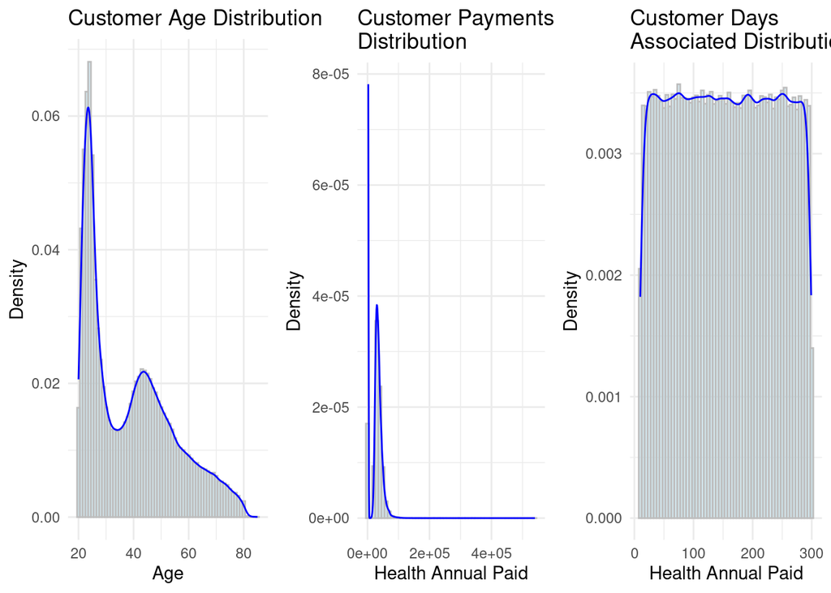

## 6.2 Categorical Attributes

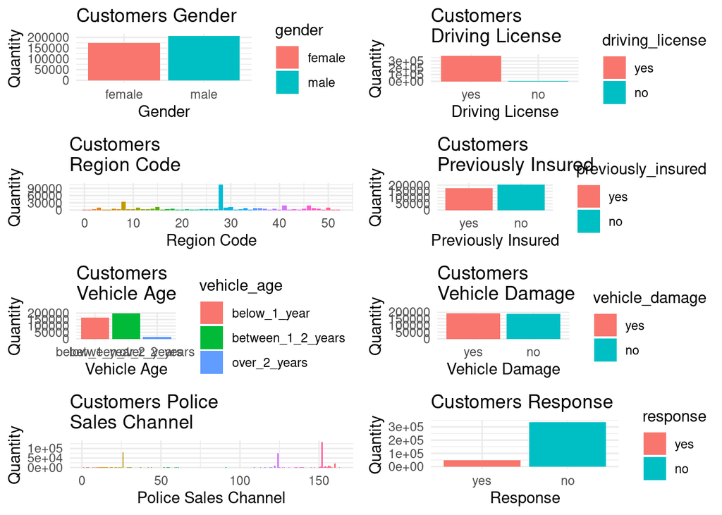

# 7 Hypothesis Validation

### 7.0.1 H1) Older customers are more likely to be interested in car insurance.

| **Characteristic** | **yes**, N = 46,710<sup>1</sup> | **no**, N = 334,399<sup>1</sup> | **p-value**<sup>2</sup> |
| --- | --- | --- | --- |
| age | 43 (35, 51) | 34 (24, 49) | <0.001 |

<sup>1</sup> Median (IQR)  
<sup>2</sup> Wilcoxon rank sum test

### 7.0.2 H2) Women are likely more interested in car insurance 🟥

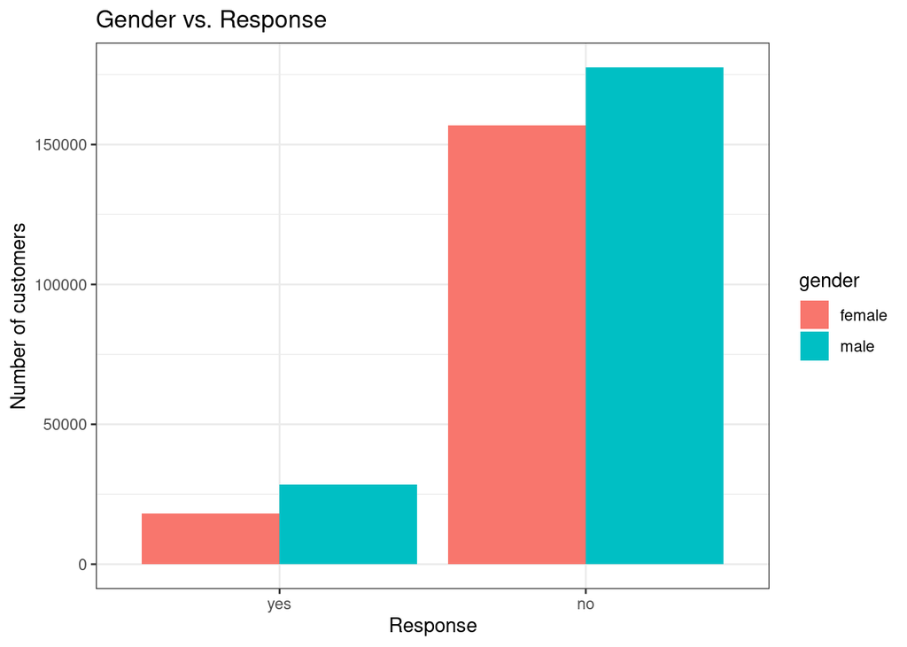

| **Characteristic** | **yes**, N = 46,710<sup>1</sup> | **no**, N = 334,399<sup>1</sup> |
| --- | --- | --- |
| gender |  |  |
| female | 18,185 (39%) | 156,835 (47%) |
| male | 28,525 (61%) | 177,564 (53%) |

<sup>1</sup> n (%)

#### 7.0.2.1 For customers interested in car insurance, 61% were men, and 39% were women. So this hypothesis is FALSE. Although, gender and response are statistically significant, i. e., are related.

### 7.0.3 H3) Customers having newer cars are more likely to be interested in car insurance

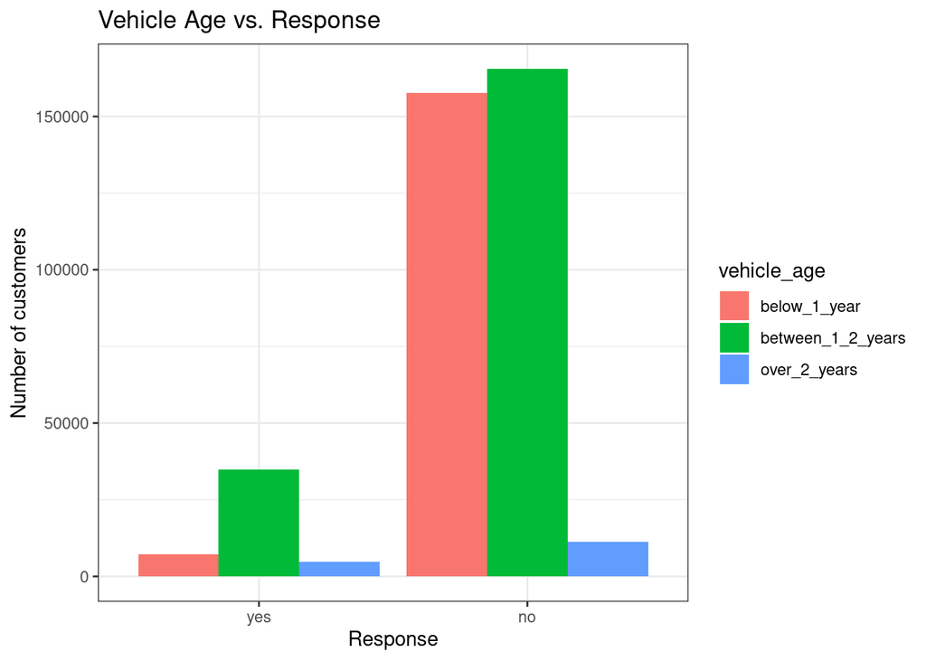

| **Characteristic** | **yes**, N = 46,710<sup>1</sup> | **no**, N = 334,399<sup>1</sup> | **p-value**<sup>2</sup> |
| --- | --- | --- | --- |
| vehicle_age |  |  | <0.001 |
| below_1_year | 7,202 (15%) | 157,584 (47%) |  |
| between_1_2_years | 34,806 (75%) | 165,510 (49%) |  |
| over_2_years | 4,702 (10%) | 11,305 (3.4%) |  |

<sup>1</sup> n (%)  
<sup>2</sup> Pearson’s Chi-squared test

#### 7.0.3.1 Customers who own a car between 1 and 2 years are more likely to be interested in the car insurance (75%). While, only 15% of the interested customers have new car.

### 7.0.4 H4) Customer with previous car damage are more likely to accept car insurance ✅

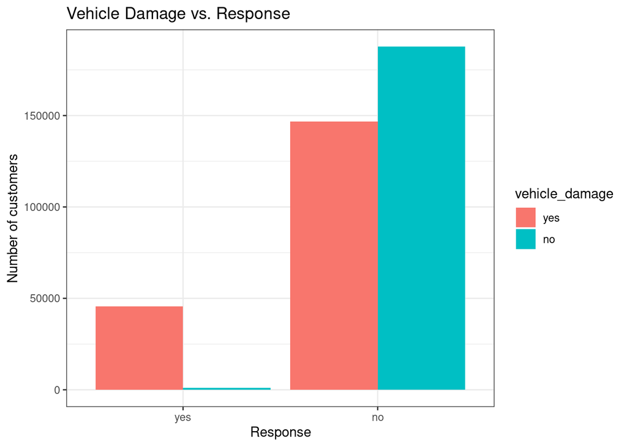

| **Characteristic** | **yes**, N = 46,710<sup>1</sup> | **no**, N = 334,399<sup>1</sup> | **p-value**<sup>2</sup> |
| --- | --- | --- | --- |
| vehicle_damage | 45,728 (98%) | 146,685 (44%) | <0.001 |

<sup>1</sup> n (%)  
<sup>2</sup> Pearson’s Chi-squared test

### 7.0.5 H5) Customers with previous car insurance are more likely to accept car insurance :

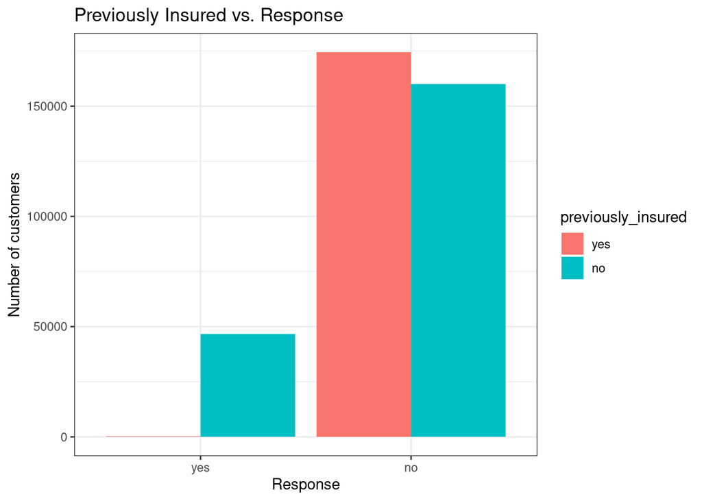

| **Characteristic** | **yes**, N = 46,710<sup>1</sup> | **no**, N = 334,399<sup>1</sup> | **p-value**<sup>2</sup> |
| --- | --- | --- | --- |
| previously_insured | 158 (0.3%) | 174,470 (52%) | <0.001 |

<sup>1</sup> n (%)  
<sup>2</sup> Pearson’s Chi-squared test

#### 7.0.5.1 Only 0.3& of customers interested in car insurance have car previously insured

### 7.0.6 H6) Interest in car insurance is greater in customers which have higher annual health insurance 🟥

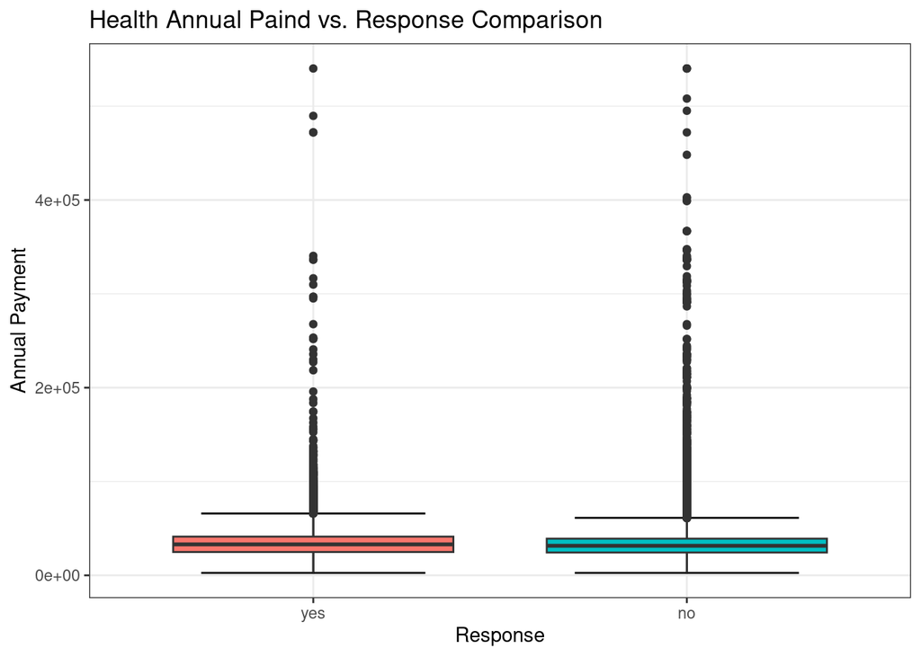

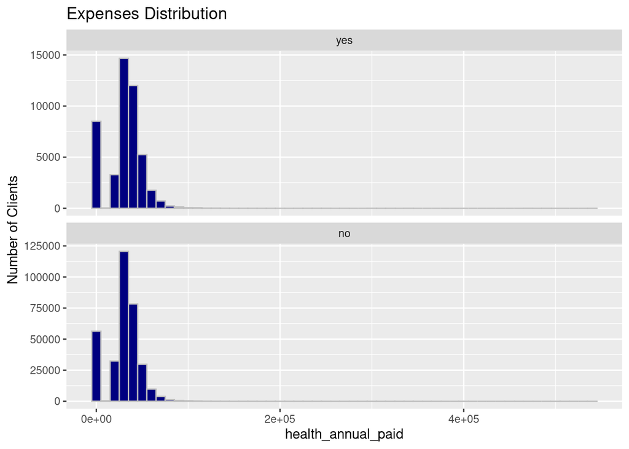

| **Characteristic** | **yes**, N = 46,710<sup>1</sup> | **no**, N = 334,399<sup>1</sup> | **p-value**<sup>2</sup> |
| --- | --- | --- | --- |
| health_annual_paid | 33,002 (24,868, 41,297) | 31,504 (24,351, 39,120) | <0.001 |

<sup>1</sup> Median (IQR)  
<sup>2</sup> Wilcoxon rank sum test

Although the health annual paid showed to be significant, we consider this hyphotesis false and will further investigate the outliers, in he next cycle for example.

### 7.0.7 H7) Customers who has health insurance for LONGER are more likely to be interested in car insurance 🟥

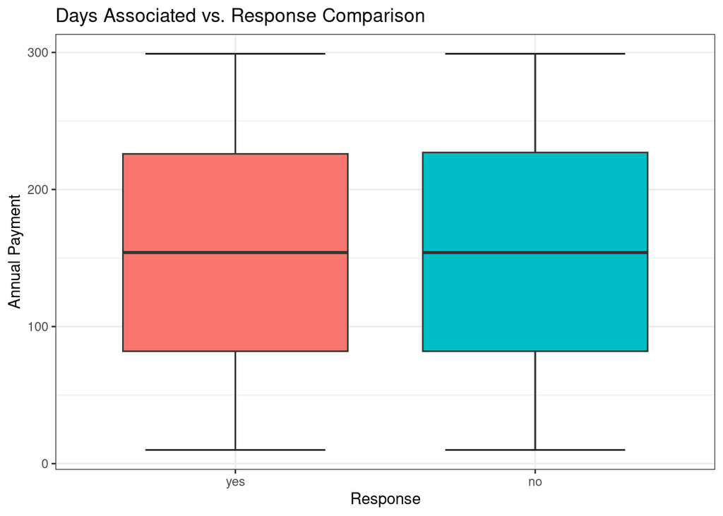

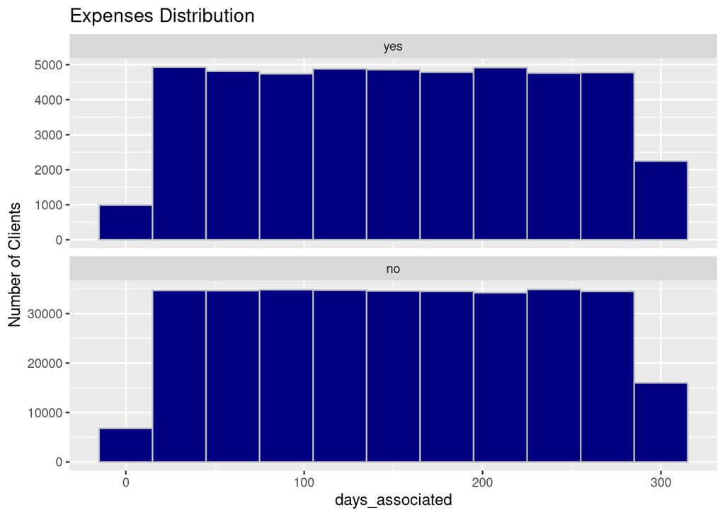

| **Characteristic** | **yes**, N = 46,710<sup>1</sup> | **no**, N = 334,399<sup>1</sup> | **p-value**<sup>2</sup> |
| --- | --- | --- | --- |
| days_associated | 154 (82, 226) | 154 (82, 227) | 0.5 |

<sup>1</sup> Median (IQR)  
<sup>2</sup> Wilcoxon rank sum test

#### 7.0.7.1 This Hypothesis is false, basically the interested customers and non-interested customers have the same amount of days associated. Yes(median:154 days, IQR: 82, 226); No (154 days, IQR: 82, 227).

### 7.0.8 Hypothesis Conclusion

| hypothesis | conclusion | relevance |
| --- | --- | --- |
| H1) OLDER customers are more likely to be interested in car insurance | True | High |
| H2) Women are likely more interested in car insurance | False | Medium |
| H3) Customers having newer cars are more likely to be interested in car insurance | False | High |
| H4) Customer with previous car damage are more likely to accept car insurance | True | High |
| H5) Customers with previous car insurance are more likely to accept car insurance | False | High |
| H6) Interest in car insurance is greater in customers which have higher annual health insurance | False | Low |
| H7) Customers who has health insurance for LONGER are more likely to be interested in car insurance | False | Low |

# 8 Multivariable Analysis

### 8.0.1 Correlation Matrix

### 8.0.2 Visualization

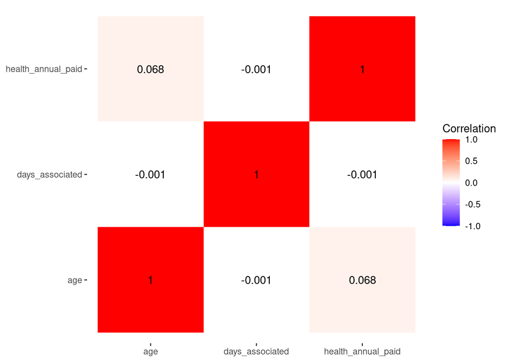

There is no high correlation between numerical variables

# 9 Data Preparation

Frequency encoding for policy_sales_channel

Target encoding for gender e region_code

## 9.1 Target encoding

## 9.2 Frequency encoding

### 9.2.1 Using the created encoders in the dataset

## 9.3 Splitting into train and test datasets

### 9.3.1 Check response proportions

| **Characteristic** | **N = 285,831**<sup>1</sup> |
| --- | --- |
| response |  |
| yes | 35,032 (12%) |
| no | 250,799 (88%) |

<sup>1</sup> n (%)

| **Characteristic** | **N = 95,278**<sup>1</sup> |
| --- | --- |
| response |  |
| yes | 11,678 (12%) |
| no | 83,600 (88%) |

<sup>1</sup> n (%)

### 9.3.2 Using tidymodels steps to continue the preprocessing

### 9.3.3 Applying the recipe

# 10 Feature Selection

```
## Time difference of 7.408854 secs
```

### 10.0.1 Show results

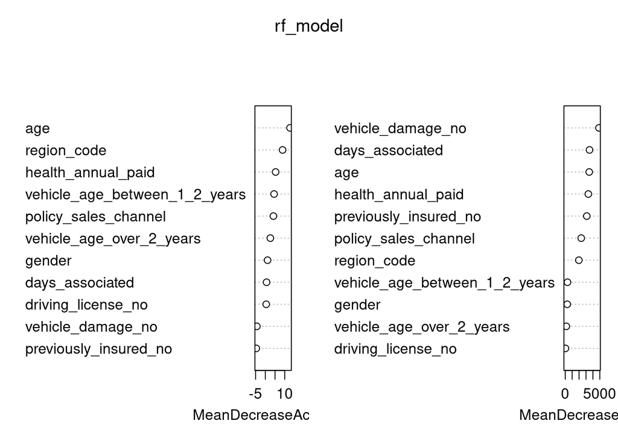

In tgis first cycle we are going to select the seven most importatnt vaiables according to the mean decrease gini

```
## [1] "vehicle_damage_no"     "days_associated"       "age"
## [4] "health_annual_paid"    "previously_insured_no" "policy_sales_channel"
## [7] "region_code"
```